# Analyse des données RéFérens III

Antoine Blanchard

28/04/2021

## Import du référentiel métier RéFérens

RéFérens (REFérentiel des Emplois-types de la recherche et de l’Enseignement Supérieur) version III est [fourni par le Ministère de l’enseignement supérieur, de la recherche et de l’innovation](https://www.data.gouv.fr/fr/datasets/referentiel-metiers-referens-iii-pour-la-filiere-des-itrf-1/), sur leur portail open data. On l’importe :

```r
data <- read.csv2("fr-esr_referentiel_metier_referens_3.csv") %>%
  mutate(Id = row_number())

variables <- data %>%
  select(-Id) %>%
  colnames()
```

Il comporte 242 lignes ou fiches métiers, conformément à ce qui est annoncé sur le portail data.gouv.fr :

> Ce jeu de données reprend les informations et nomenclatures concernant les 242 métiers des ingénieurs et personnels techniques de recherche et de formation (ITRF) et des ingénieurs et personnels techniques de la recherche (ITA) décrits dans le répertoire des branches d’activités professionnelles et des emplois-types, dénommé RéFérens (REFérentiel des Emplois-types de la recherche et de l’Enseignement Supérieur).

## Transformation des données

On définit les chaînes de caractère qui seront comptées dans le document comme des occurrences du terme “données” :

```r
donnees <- "Donnees|donnees|Données|données|Donnee|donnee|Donnée|donnée"
```

On dénombre, pour chaque cellule, les occurrences du terme “données” et on les ajoute aux données brutes pour former le tableau **data_filtered** :

```r
denombrement <- data %>%
  column_to_rownames("Id") %>%
  #select(Nom des colonnes, séparées par une virgule) %>%
  mutate_all(str_count, donnees) %>%
  mutate(somme = rowSums(.)) %>%
  rownames_to_column("Id") %>%
  filter(somme > 0) %>%
  arrange(desc(somme))

# Classer les corps dans l'ordre hiérarchique
ordre_corps <- c("ATRF", "TECH", "AI", "IE", "IR")

data_filtered <- data %>%
  filter(Id %in% denombrement$Id) %>%
  mutate(Id = as.character(Id),
         referens_cs=factor(referens_cs, levels = ordre_corps)) %>%
  left_join(denombrement %>% select(Id, somme), by = "Id") %>%
  arrange(desc(somme))
```

# Analyse des données

## Distribution des fiches métiers

On trace la distribution des 154 fiches métiers selon le nombre de fois où apparaît le terme “données” :

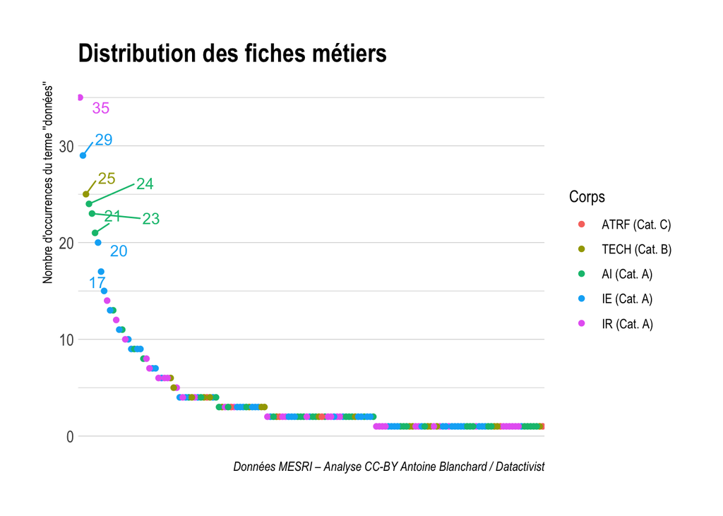

```r
data_filtered %>%
    mutate(referens_id = fct_reorder(referens_id, -somme),
         referens_cs=factor(referens_cs, levels = ordre_corps)) %>%
  ggplot(aes(x = referens_id, y = somme, color=referens_cs, label=somme)) +
  geom_point() +
    geom_text_repel(box.padding=0.5,max.overlaps = Inf, aes(label=ifelse(somme>=17,somme,'')), show.legend=FALSE) +
  labs(x="Rang", y="Nombre d'occurrences du terme ''données''", color="Corps",
       title="Distribution des fiches métiers",
       caption="Données MESRI – Analyse CC-BY Antoine Blanchard / Datactivist") +
    scale_color_hue(labels = c("ATRF (Cat. C)", "TECH (Cat. B)", "AI (Cat. A)", "IE (Cat. A)", "IR (Cat. A)")) +
  theme_ipsum() +
  theme(axis.title.x=element_blank(),
        axis.text.x=element_blank(),
        axis.ticks.x=element_blank(),
        panel.grid.major.x = element_blank())
```

On observe une distribution fortement asymétrique, avec un décrochement à y=17. Nous sommes donc tentés de placer un seuil entre les fiches métiers qui forment une continuité de y=15 à y=1 et les 8 métiers où le terme apparaît 17 fois ou plus.

On étiquette ces 8 métiers (les autres étiquettes s’affichent au survol) :

```r
distribution_corps_avec_intitule <- data_filtered %>%
    mutate(referens_id = fct_reorder(referens_id, -somme),
         referens_cs=factor(referens_cs, levels = ordre_corps)) %>%
  ggplot(aes(x = referens_id, y = somme, color=referens_cs, label=referens_intitule)) +
  geom_point() +
    geom_text_repel(size=2.5,box.padding=0.5,max.overlaps = Inf,force=8, aes(label=ifelse(somme>=17,referens_intitule,'')), show.legend=FALSE,
    nudge_x           = 0.2,
    direction         = "both",
    segment.size      = 0.2,
    segment.curvature = -0.1,
    segment.inflect=FALSE) +
  labs(x="Rang", y="Nombre d'occurrences du terme \"données\"", color="Corps",
       title="Distribution des fiches métiers",
       caption="Données MESRI – Analyse CC-BY Antoine Blanchard / Datactivist") +
    scale_color_hue(labels = c("ATRF (Cat. C)", "TECH (Cat. B)", "AI (Cat. A)", "IE (Cat. A)", "IR (Cat. A)")) +
  theme_ipsum() +
  theme(axis.title.x=element_blank(),
        axis.text.x=element_blank(),
        axis.ticks.x=element_blank(),
        panel.grid.major.x = element_blank())
```

```r
distribution_interactive <- distribution_corps_avec_intitule + geom_point_interactive(aes(tooltip = referens_intitule), size = 2)
girafe(code = print(distribution_interactive))
```

[interactive chart not shown]

Et sous forme de table :

```r
top_metiers <- data_filtered %>%
  filter(somme >= 17) %>%
  arrange(desc(somme)) %>%
  select (referens_intitule, bap, referens_fap, referens_cs, somme, Id)

kable(top_metiers, caption = "Métiers incluant au moins 17 fois le terme 'données'")
```

Métiers incluant au moins 17 fois le terme ‘données’

| referens_intitule | bap | referens_fap | referens_cs | somme | Id |
| --- | --- | --- | --- | --- | --- |
| Ingénieur-e de recherche en production, traitement et analyse de données | BAP D - Sciences Humaines et Sociales | Production, traitement et analyse des données | IR | 35 | 123 |
| Ingénieur-e d’études en production, traitement, analyse de données et enquêtes | BAP D - Sciences Humaines et Sociales | Production, traitement et analyse des données | IE | 29 | 160 |
| Technicien-ne en production, traitement de données et enquêtes | BAP D - Sciences Humaines et Sociales | Production, traitement et analyse des données | TECH | 25 | 101 |
| Assistant-e ingénieur-e en production, traitement de données et enquêtes | BAP D - Sciences Humaines et Sociales | Production, traitement et analyse des données | AI | 24 | 106 |
| Assistant-e ingénieur-e biologiste en traitement de données | BAP A - Sciences du vivant, de la terre et de l’environnement | Biologie et santé, Sciences de la vie et de la terre | AI | 23 | 125 |
| Assistant-e statisticien-ne | BAP E - Informatique, Statistiques et Calcul scientifique | Statistiques | AI | 21 | 161 |
| Administrateur-trice de bases de données / Intégrateur d’applications | BAP E - Informatique, Statistiques et Calcul scientifique | Ingénierie technique et de production | IE | 20 | 116 |
| Ingénieur-e statisticien-ne | BAP E - Informatique, Statistiques et Calcul scientifique | Statistiques | IE | 17 | 215 |

On constate que ce sont majoritairement des métiers AI et IE, majoritairement en soutien à la recherche (BAP A et D).

## Occurrences de l’expression “données” par champ

Dans quelles colonnes (variables) du jeu de données trouve-t-on le plus le terme “données” ?

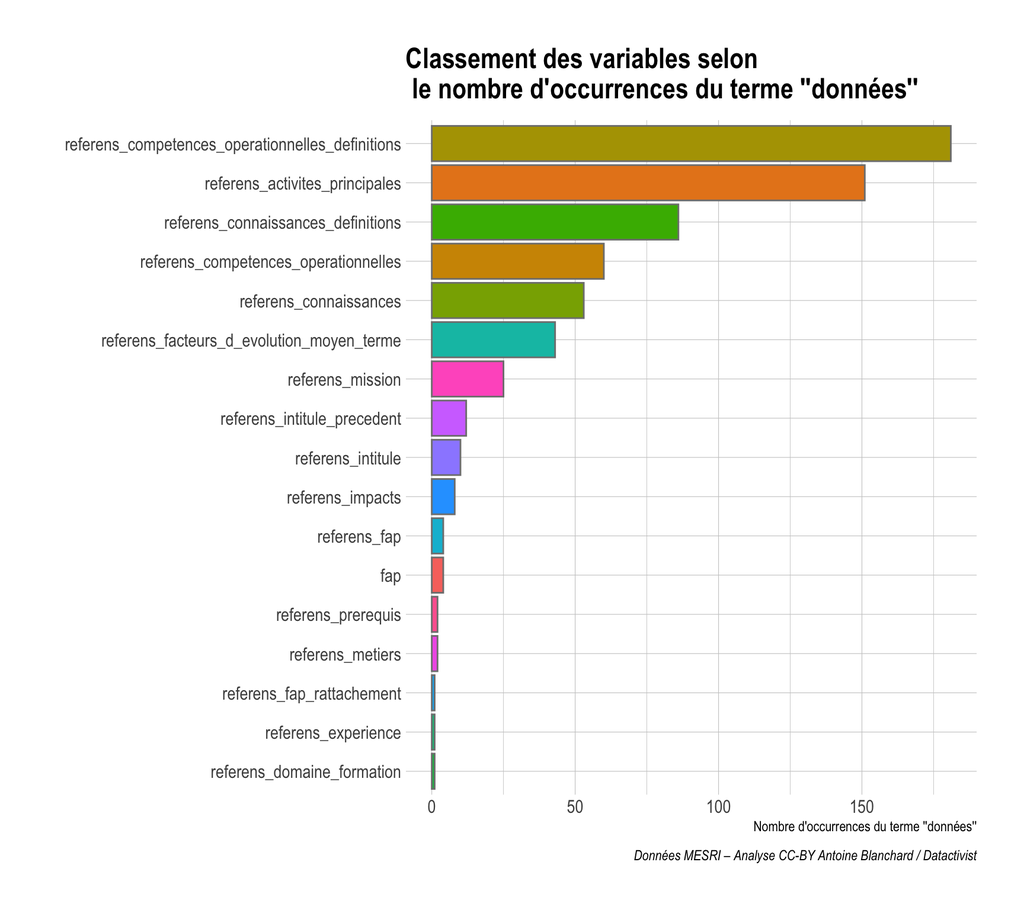

```r
denombrement %>%
  select(-somme) %>%
  column_to_rownames("Id") %>%
  summarise_all(sum) %>%
  rownames_to_column("Id") %>%
  gather("variable", "somme", -Id) %>%
  filter(somme > 0) %>%
  ggplot(aes(x=fct_reorder(variable, somme), y = somme)) +
  geom_col(aes(fill = variable), color = "grey50") +
  labs(x = "", y = "Nombre d'occurrences du terme ''données''",
       title="Classement des variables selon \n le nombre d'occurrences du terme ''données''",
       caption="Données MESRI – Analyse CC-BY Antoine Blanchard / Datactivist")+
  coord_flip()+
  theme_ipsum() +
  theme(legend.position = "none")
```

Comme on pouvait s’y attendre, le terme données apparaît le plus dans les champs qui décrivent les compétences opérationnelles (rang 1) et les activités principales (rang 2) des fiches métiers. Il apparaît assez peu dans l’intitulé des fiches métiers (voir ci-après), qui est au 9e rang, précédé du champ “intitulé précédent” qui mérite d’être creusé pour comprendre pourquoi certaines occurrences ont disparu (voir plus loin). Au 6e rang, donc assez haut, on trouve le champ “Facteurs d’évolution à moyen terme” du métier qui vise, selon la documentation de RéFérens, à identifier les facteurs clés et en déduire leur impact qualitatif sur le métier.

On regarde quelle place le terme “données” occupe comparativement aux autres termes les plus utilisés dans le champ “Facteurs d’évolution à moyen terme” :

```r
data_filtered %>%
  unnest_tokens(word, referens_facteurs_d_evolution_moyen_terme) %>%
      mutate(stem = wordStem(word)) %>%
  anti_join(get_stopwords(language = "fr")) %>%
  count(stem, sort = TRUE) %>%
  filter(n >25)
```

```
##       stem   n
## 1 développ 108
## 2  gestion  45
## 3    donné  43
## 4   evolut  36
## 5 techniqu  34
## 6 numériqu  30
## 7   nouvel  26
## 8 recherch  26
```

Le terme “données” est même le terme qui revient le plus fréquemment (43 occurrences) dans le champ “Facteurs d’évolution à moyen terme” des fiches métiers après “développement” et apparentés (108) et “gestion” (45).

## Liste des 11 métiers dont l’intitulé contient l’expression “données”

```r
intitule_TRUE <- denombrement %>%
  filter(denombrement$referens_intitule >0 | denombrement$referens_metiers >0)

intitule_filtered <- data_filtered %>%
  filter(Id %in% intitule_TRUE$Id) %>%
  mutate(Id = as.character(Id),
         referens_cs=factor(referens_cs, levels = ordre_corps)) %>%
  left_join(data_filtered %>% select(Id, somme), by = "Id") %>%
  select(referens_intitule, referens_metiers, bap, referens_fap, referens_cs, Id) %>%
  arrange(bap,referens_cs)

kable(intitule_filtered, caption = "Métiers incluant le terme \"données\" dans leur intitulé")
```

Métiers incluant le terme “données” dans leur intitulé

| referens_intitule | referens_metiers | bap | referens_fap | referens_cs | Id |
| --- | --- | --- | --- | --- | --- |
| Assistant-e ingénieur-e biologiste en traitement de données |  | BAP A - Sciences du vivant, de la terre et de l’environnement | Biologie et santé, Sciences de la vie et de la terre | AI | 125 |
| Ingénieur-e biologiste en traitement de données | epidémiologiste\|bio informaticien | BAP A - Sciences du vivant, de la terre et de l’environnement | Biologie et santé, Sciences de la vie et de la terre | IE | 230 |
| Ingénieur-e biologiste en analyse de données | epidémiologiste\|bio informaticien | BAP A - Sciences du vivant, de la terre et de l’environnement | Biologie et santé, Sciences de la vie et de la terre | IR | 178 |
| Technicien-ne en production, traitement de données et enquêtes |  | BAP D - Sciences Humaines et Sociales | Production, traitement et analyse des données | TECH | 101 |
| Assistant-e ingénieur-e en production, traitement de données et enquêtes |  | BAP D - Sciences Humaines et Sociales | Production, traitement et analyse des données | AI | 106 |
| Ingénieur-e d’études en production, traitement, analyse de données et enquêtes |  | BAP D - Sciences Humaines et Sociales | Production, traitement et analyse des données | IE | 160 |
| Ingénieur-e de recherche en production, traitement et analyse de données |  | BAP D - Sciences Humaines et Sociales | Production, traitement et analyse des données | IR | 123 |
| Administrateur-trice de bases de données / Intégrateur d’applications | administrateur de bases de données (dba) | BAP E - Informatique, Statistiques et Calcul scientifique | Ingénierie technique et de production | IE | 116 |
| Chargé-e de l’édition de corpus numériques | éditeur de données scientifiques | BAP F - Culture, Communication, Production et diffusion des savoirs | Édition et graphisme | IE | 91 |
| Chargé-e du traitement des données scientifiques |  | BAP F - Culture, Communication, Production et diffusion des savoirs | Information scientifique et technique, documentation et collections patrimoniales | IE | 146 |
| Gestionnaire de données et indicateurs patrimoniaux |  | BAP G - Patrimoine immobilier, Logistique, Restauration et Prévention | Patrimoine immobilier | AI | 80 |

Ensemble, ces deux listes de métiers obtenues par deux méthodes différentes (que le terme apparaisse au moins 17 fois ou qu’il apparaisse dans l’intitulé) forment une liste de 13 métiers-types que l’on peut qualifier de “métiers des données”.

```r
metiers_donnee <- full_join(intitule_filtered,top_metiers,by=c("referens_intitule","bap","referens_fap","referens_cs","Id"))  %>%
  arrange(bap,referens_cs)

kable(metiers_donnee, caption = "Métiers des données")
```

Métiers des données

| referens_intitule | referens_metiers | bap | referens_fap | referens_cs | Id | somme |
| --- | --- | --- | --- | --- | --- | --- |
| Assistant-e ingénieur-e biologiste en traitement de données |  | BAP A - Sciences du vivant, de la terre et de l’environnement | Biologie et santé, Sciences de la vie et de la terre | AI | 125 | 23 |
| Ingénieur-e biologiste en traitement de données | epidémiologiste\|bio informaticien | BAP A - Sciences du vivant, de la terre et de l’environnement | Biologie et santé, Sciences de la vie et de la terre | IE | 230 | NA |
| Ingénieur-e biologiste en analyse de données | epidémiologiste\|bio informaticien | BAP A - Sciences du vivant, de la terre et de l’environnement | Biologie et santé, Sciences de la vie et de la terre | IR | 178 | NA |
| Technicien-ne en production, traitement de données et enquêtes |  | BAP D - Sciences Humaines et Sociales | Production, traitement et analyse des données | TECH | 101 | 25 |
| Assistant-e ingénieur-e en production, traitement de données et enquêtes |  | BAP D - Sciences Humaines et Sociales | Production, traitement et analyse des données | AI | 106 | 24 |
| Ingénieur-e d’études en production, traitement, analyse de données et enquêtes |  | BAP D - Sciences Humaines et Sociales | Production, traitement et analyse des données | IE | 160 | 29 |
| Ingénieur-e de recherche en production, traitement et analyse de données |  | BAP D - Sciences Humaines et Sociales | Production, traitement et analyse des données | IR | 123 | 35 |
| Assistant-e statisticien-ne | NA | BAP E - Informatique, Statistiques et Calcul scientifique | Statistiques | AI | 161 | 21 |
| Administrateur-trice de bases de données / Intégrateur d’applications | administrateur de bases de données (dba) | BAP E - Informatique, Statistiques et Calcul scientifique | Ingénierie technique et de production | IE | 116 | 20 |
| Ingénieur-e statisticien-ne | NA | BAP E - Informatique, Statistiques et Calcul scientifique | Statistiques | IE | 215 | 17 |
| Chargé-e de l’édition de corpus numériques | éditeur de données scientifiques | BAP F - Culture, Communication, Production et diffusion des savoirs | Édition et graphisme | IE | 91 | NA |
| Chargé-e du traitement des données scientifiques |  | BAP F - Culture, Communication, Production et diffusion des savoirs | Information scientifique et technique, documentation et collections patrimoniales | IE | 146 | NA |
| Gestionnaire de données et indicateurs patrimoniaux |  | BAP G - Patrimoine immobilier, Logistique, Restauration et Prévention | Patrimoine immobilier | AI | 80 | NA |

## Occurrences de l’expression “données” par BAP

Proportion des fiches métiers qui contiennent l’expression “données” par BAP :

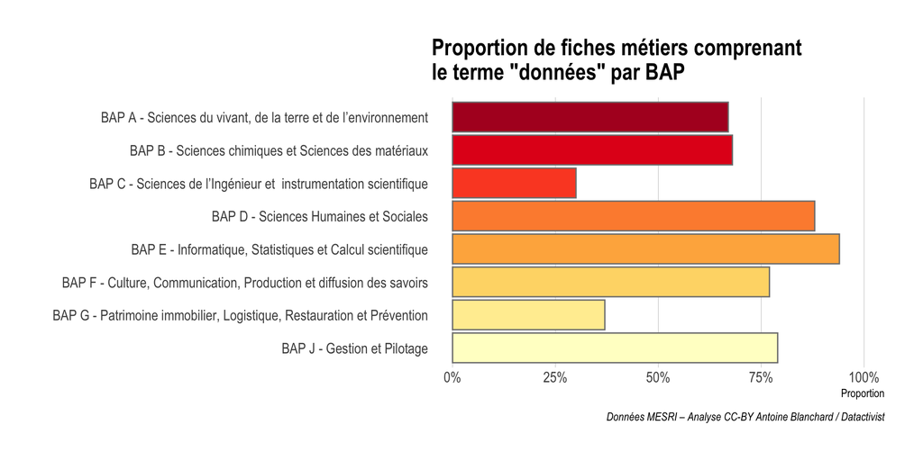

```r
BAP_filtered <- data_filtered %>%
  count(bap) %>%
  arrange(bap)

BAP <- data %>%
  count(bap)

BAP_filtered_pourcentage <- BAP_filtered %>%
  left_join(BAP, BAP_filtered, by = "bap") %>%
  mutate(pourcentage_bap=round(n.x/n.y,2),
         bap=fct_reorder(bap, bap, .desc = TRUE))

BAP_filtered_pourcentage %>%
  ggplot(aes(x = bap, y = pourcentage_bap)) +
  geom_col(aes(fill = bap), color = "grey50") +
  labs(x = "", y = "Proportion",
       title="Proportion de fiches métiers comprenant \nle terme \"données\" par BAP",
    caption="Données MESRI – Analyse CC-BY Antoine Blanchard / Datactivist") +
  theme_ipsum() +
  coord_flip() +
  theme_ipsum(grid="X") +
  theme(legend.position = "none") +
  scale_fill_manual(values = brewer.pal(8, "YlOrRd")) +
  scale_y_continuous(labels = scales::percent, limits = c(0,1))
```

On constate que les BAP E et D possèdent en proportion la plus grande part de métiers liés aux données : c’est intéressant de voir le soutien à la recherche en SHS si haut. Les BAP A, B et C, qui concernent directement le soutien à la recherche, sont moins concernés par les données que les BAP F et J qui sont liés à l’administration de l’université et se retrouvent plutôt dans l’administration centrale.

## Occurrences de l’expression “données” par corps

Proportion des fiches métiers qui contiennent l’expression “données” par corps :

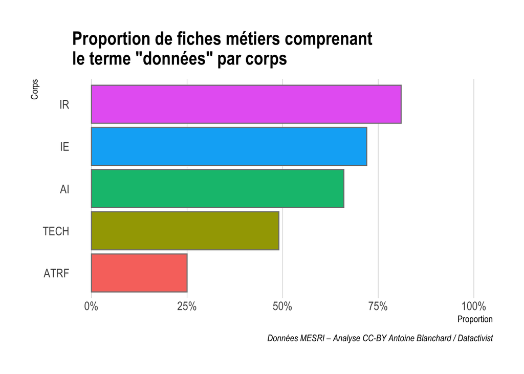

```r
corps_filtered <- data_filtered %>%
  count(referens_cs) %>%
  arrange(desc(n))

corps <- data %>%
  count(referens_cs)

corps_filtered_pourcentage <- corps_filtered %>%
  left_join(corps, corps_filtered, by = "referens_cs") %>%
  mutate(pourcentage_corps=round(n.x/n.y,2),
         referens_cs=factor(referens_cs, levels = ordre_corps))

corps_filtered_pourcentage %>%
  ggplot(aes(x = referens_cs, y = pourcentage_corps)) +
  geom_col(aes(fill = referens_cs), color = "grey50") +
  labs(x = "Corps", y = "Proportion",
       title="Proportion de fiches métiers comprenant \nle terme \"données\" par corps",
      caption="Données MESRI – Analyse CC-BY Antoine Blanchard / Datactivist") +
  coord_flip() +
  theme_ipsum(grid="X") +
  theme(legend.position = "none") +
  scale_y_continuous(labels = scales::percent, limits = c(0,1))
```

On constate que la proportion de métiers liés aux données varie en même temps que l’ordre hiérarchique : elle est plus grande pour les corps ayant le plus de missions d’encadrement.

## Fréquence de l’expression “données” par BAP et par corps

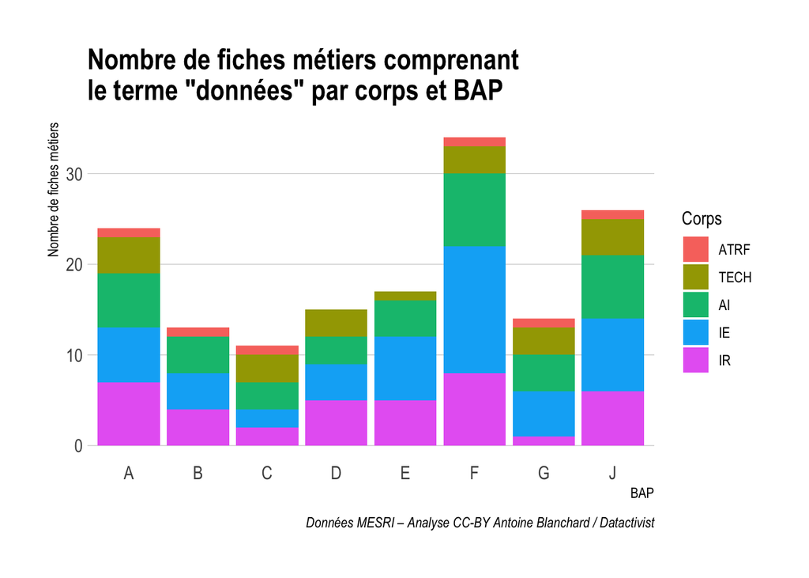

```r
data_filtered %>%
      mutate(referens_cs=factor(referens_cs, levels = ordre_corps)) %>%
  ggplot(aes(x = referens_bap_id, fill=referens_cs)) +
    geom_bar() +
      labs(x= "BAP", y = "Nombre de fiches métiers", fill="Corps",
           title="Nombre de fiches métiers comprenant \nle terme \"données\" par corps et BAP",
         caption="Données MESRI – Analyse CC-BY Antoine Blanchard / Datactivist") +
theme_ipsum(grid="Y")
```

En valeur absolue, la BAP F Culture, Communication, Production et diffusion des savoirs concentre le plus grand nombre de fiches métiers liées aux données, grâce à un nombre très important de métiers appartenant au corps des IE.

Nous voulons savoir quels sont ces métiers IE de la BAP F.

## Liste des métiers IE de la BAP F liés aux données

```r
temp <- data_filtered %>%
  filter(referens_cs %in% c("IE") & referens_bap_id %in% c("F")) %>%
  select (referens_intitule, bap, referens_fap, referens_cs, somme)

  kable(temp, caption="Métiers IE de la BAP F liés aux données")
```

Métiers IE de la BAP F liés aux données

| referens_intitule | bap | referens_fap | referens_cs | somme |
| --- | --- | --- | --- | --- |
| Chargé-e de l’édition de corpus numériques | BAP F - Culture, Communication, Production et diffusion des savoirs | Édition et graphisme | IE | 11 |
| Chargé-e des systèmes d’information documentaire | BAP F - Culture, Communication, Production et diffusion des savoirs | Information scientifique et technique, documentation et collections patrimoniales | IE | 10 |
| Chargé-e d’archives | BAP F - Culture, Communication, Production et diffusion des savoirs | Information scientifique et technique, documentation et collections patrimoniales | IE | 9 |
| Chargé-e du traitement des données scientifiques | BAP F - Culture, Communication, Production et diffusion des savoirs | Information scientifique et technique, documentation et collections patrimoniales | IE | 9 |
| Chargé-e de collections muséales | BAP F - Culture, Communication, Production et diffusion des savoirs | Information scientifique et technique, documentation et collections patrimoniales | IE | 4 |
| Chargé-e de fabrication et graphisme | BAP F - Culture, Communication, Production et diffusion des savoirs | Édition et graphisme | IE | 3 |
| Traducteur-trice | BAP F - Culture, Communication, Production et diffusion des savoirs | Information scientifique et technique, documentation et collections patrimoniales | IE | 3 |
| Chargé-e des ressources documentaires | BAP F - Culture, Communication, Production et diffusion des savoirs | Information scientifique et technique, documentation et collections patrimoniales | IE | 3 |
| Ingénieur-e pour l’enseignement numérique | BAP F - Culture, Communication, Production et diffusion des savoirs | Productions audiovisuelles, productions pédagogiques et web | IE | 2 |
| Ingénieur-e en technologies de l’information et de la communication | BAP F - Culture, Communication, Production et diffusion des savoirs | Productions audiovisuelles, productions pédagogiques et web | IE | 1 |
| Animateur-trice de communautés | BAP F - Culture, Communication, Production et diffusion des savoirs | Médiation scientifique, culture et communication | IE | 1 |
| Chargé-e de communication | BAP F - Culture, Communication, Production et diffusion des savoirs | Médiation scientifique, culture et communication | IE | 1 |
| Chargé-e de médiation scientifique | BAP F - Culture, Communication, Production et diffusion des savoirs | Médiation scientifique, culture et communication | IE | 1 |
| Chargé-e de projets culturels | BAP F - Culture, Communication, Production et diffusion des savoirs | Médiation scientifique, culture et communication | IE | 1 |

## Dispersion des fiches métiers par corps

Question : on a vu que les corps IE et IR possèdent proportionnellement plus de métiers liés **aux** données, mais dans quels corps trouve-t-on les métiers **des** données (c’est-à-dire où le terme apparaît le plus fréquemment) ?

On trace la dispersion des fiches métiers par corps selon les occurrences du mot “données”, avec une représentation par boxplot :

```r
dispersion_corps <- data_filtered %>%
      mutate(referens_cs=factor(referens_cs, levels = ordre_corps)) %>%
  ggplot(aes(x = referens_cs, y = somme, color=referens_cs)) +
    geom_boxplot()+
  geom_jitter(shape=16, position=position_jitter (0.2)) +
    labs(x= "Corps", y = "Nombre d'occurrences du terme ''données''", color="Corps",
         title="Dispersion des fiches métiers comprenant \nle terme \"données\" par corps",
         caption="Données MESRI – Analyse CC-BY Antoine Blanchard / Datactivist") +
  theme_ipsum() +
    theme(legend.position = "none")
```

```r
dispersion_interactive <- dispersion_corps + geom_point_interactive(aes(tooltip = referens_intitule), size = 2)
girafe(code = print(dispersion_interactive))
```

[interactive chart not shown]

Il apparaît que les corps IE et IR ont la distribution la plus étirée vers le haut, ce sont ceux où l’on trouve le plus de métiers **des** données.

## Métiers des BAP E, F, G, J où “données” apparaît comme facteur d’évolution moyen terme

```r
evolution_metiers <- data_filtered %>%
  mutate(Id = as.character(Id)) %>%
  left_join(denombrement %>% select(Id, referens_facteurs_d_evolution_moyen_terme), by = "Id") %>%
  filter(referens_facteurs_d_evolution_moyen_terme.y >0) %>%
  filter(referens_bap_id %in% c("E", "F", "G", "J")) %>%
  group_by(bap) %>%
  arrange(referens_cs, .by_group = TRUE)

evolution_metiers_extrait <- evolution_metiers %>%
  select (referens_intitule, bap, referens_fap, referens_cs, somme)

  kable(evolution_metiers_extrait, caption = "Métiers où 'données' apparaît comme facteur d'évolution moyen terme")
```

Métiers où ‘données’ apparaît comme facteur d’évolution moyen terme

| referens_intitule | bap | referens_fap | referens_cs | somme |
| --- | --- | --- | --- | --- |
| Assistant-e statisticien-ne | BAP E - Informatique, Statistiques et Calcul scientifique | Statistiques | AI | 21 |
| Ingénieur-e statisticien-ne | BAP E - Informatique, Statistiques et Calcul scientifique | Statistiques | IE | 17 |
| Ingénieur-e en calcul scientifique | BAP E - Informatique, Statistiques et Calcul scientifique | Calcul scientifique | IE | 4 |
| Administrateur-trice systèmes et réseaux | BAP E - Informatique, Statistiques et Calcul scientifique | Ingénierie technique et de production | IE | 1 |
| Expert-e en information statistique | BAP E - Informatique, Statistiques et Calcul scientifique | Statistiques | IR | 10 |
| Expert-e en calcul scientifique | BAP E - Informatique, Statistiques et Calcul scientifique | Calcul scientifique | IR | 2 |
| Assistant-e d’édition | BAP F - Culture, Communication, Production et diffusion des savoirs | Édition et graphisme | AI | 2 |
| Chargé-e de l’édition de corpus numériques | BAP F - Culture, Communication, Production et diffusion des savoirs | Édition et graphisme | IE | 11 |
| Chargé-e d’archives | BAP F - Culture, Communication, Production et diffusion des savoirs | Information scientifique et technique, documentation et collections patrimoniales | IE | 9 |
| Chargé-e du traitement des données scientifiques | BAP F - Culture, Communication, Production et diffusion des savoirs | Information scientifique et technique, documentation et collections patrimoniales | IE | 9 |
| Responsable éditorial-e | BAP F - Culture, Communication, Production et diffusion des savoirs | Édition et graphisme | IR | 6 |
| Dessinateur-trice gestionnaire et indicateurs patrimoniaux | BAP G - Patrimoine immobilier, Logistique, Restauration et Prévention | Patrimoine immobilier | TECH | 4 |

Dans ces BAP liés à l’administration centrale, on remarque l’absence de la BAP J et la quasi-absence de la BAP G, dont aucun métier ne prend la donnée en compte pour leur évolution moyen terme. Pourtant, les entretiens que nous avons menés montrent que ces domaines de la gestion du patrimoine immobilier et du pilotage sont fortement amenés à évoluer dans le contexte de la donnée.

## Métiers où “données” apparaît comme “intitulé précédent” et a disparu de l’intitulé actuel

```r
suppression_metiers <- denombrement %>%
  filter(referens_intitule_precedent >0 & referens_intitule ==0) %>%
  mutate(Id = as.character(Id)) %>%
  select(Id) %>%
  left_join(data_filtered, by = "Id") %>%
  select (referens_intitule, referens_intitule_precedent, bap, referens_fap, referens_cs) %>%
  arrange(referens_cs)

kable(suppression_metiers, caption = "Métiers dont l'ancien intitulé incluait le terme 'données' contrairement à l'intitulé actuel")
```

Métiers dont l’ancien intitulé incluait le terme ‘données’ contrairement à l’intitulé actuel

| referens_intitule | referens_intitule_precedent | bap | referens_fap | referens_cs |
| --- | --- | --- | --- | --- |
| Technicien-ne d’exploitation, d’assistance et de traitement de l’information | Technicien d’exploitation, de maintenance et de traitement des données | BAP E - Informatique, Statistiques et Calcul scientifique | Ingénierie des systèmes d’information\|Ingénierie technique et de production | TECH |
| Gestionnaire d’application / assistance support | Gestionnaire de base de données | BAP E - Informatique, Statistiques et Calcul scientifique | Ingénierie des systèmes d’information | AI |

# TO DO

## Afficher le terme “données” en kwic (keyword-in-context) et représenter son voisinage lexical (qualificatifs, verbes relatifs à des processus managériaux…)

## Répéter les étapes avec le terme “archives”